# SCS 2017: Exploring Regression with Linear Hypotheses

Georges Monette

17:04 08 March 2017

Generated: March 08, 2017 17:04

# Introduction

This ‘html-flavoured’ [R Markdown](https://www.rstudio.com/wp-content/uploads/2015/02/rmarkdown-cheatsheet.pdf) script illustrates a number of skills and concepts you should master to analyze data using regression in R.

1. Formulating and interpreting models with interaction terms.
2. Graphical diagnostics using various residual plots, leverage plots and added-variable plots.
3. Using lattice graphics to display the model and data.
4. Refining lattice graphics for presentations.
5. Formulating specific questions and addressing them with linear hypotheses and estimators.
6. Dealing with heteroscedasticity: transforming the response or adapting the model. In this example we illustrate how to use a generalized least-squares fit using the ‘gls’ function in the ‘nlme’ package.

# Exploring Regressions with Linear Hypotheses

This script illustrates the use of the general linear hypothesis (GLH) and corresponding linear estimators to explore and interpret regression analyses. Linear hypotheses allow us to formulate and test many types of specific questions about the subject matter of the study.

Each estimated coefficient that appears in the usual output of a regression answers a specific question about the data through the model.

However, when you carefully interpret estimated coefficients, you often find that most of them are of little or no interest in understanding the substance of the study. Conversely, most questions of real interest are not answered directly through the estimated coefficients.

So you need to know how to formulate and ask meaningful questions, indenpendently of the particular parametrization of your model. Although not all questions can be framed with linear hypotheses, knowing how to use them greatly enlarges the scope of your analyses.

The ‘wald’ function in the ‘spida2’ package is designed to make it easier to find answers to many common questions involving linear hypotheses. For more complex questions, it can be used with the ‘Lfx’ function to construct linear hypothesis matrices.

Linear hypotheses for models using general parametric splines (using the ‘gsp’ function in ‘spida2’) can be generated with the ‘sc’ function.

Note that in SAS, in PROC GLM, linear hypotheses are generated with the [‘ESTIMATE’ and ‘CONTRAST’ statements](https://support.sas.com/resources/papers/proceedings11/351-2011.pdf).

## Initial setup (this part would be hidden in a report)

We first set up some options. This is optional.

## Loading packages

The first few time you use this script, you need to execute it line by line to try to understand as much of it as possible and to install any packages that need to be installed.

If you get an error that a package is not installed just install it with:

```r
# install.packages("<name of package>")
# where you substitute the <name of the package> to install
```

Much of the really interesting work in R uses specialized packages. ‘Mature’ packages are usually uploaded to ‘CRAN’ and can be installed with, for example:

```r
# install.packages('car')
```

Many ‘maturing’ packages are incubated by their authors on GitHub and can be installed (after having installed the ‘devtools’ package) with, for example:

```r
devtools::install_github('gmonette/spida2')
```

Once a package is installed, you use it in an R session with the ‘library’ function.

If a package is undergoing frequent changes, as is the case for the ‘spida2’ package, it’s a good idea to reinstall it frequently. To reinstall a package, you should install it *before* loading it with ‘library()’.

Here are the packages we will need for this script. Note that you can install each package anywhere in the script before you actually need to use the functions or data in the package. To get information on a package, use, for example:

```r
help(package=spida2)
```

```r
library(spida2) # devtools::install_github('gmonette/spida2')
library(p3d)  # devtools::install_github('gmonette/p3d')
```

```r
library(lattice) # for graphs with panels
library(latticeExtra) # to combine plots together
library(gridExtra)  # for grid.arrange
library(magrittr) # for function pipelines
library(car) # Companion to Applied Regression by John Fox
library(nlme) # for the 'gls' function
```

## Exploring the Prestige data set

The ‘Prestige’ data set is in the car package so it’s easy to load – in contrast with typical data sets where most of your effort is spent getting the data in shape.

```r
data(Prestige)  # with some packages you need to do this to 'load' the data frame
```

A quick look at the data set:

```r
dim(Prestige)
```

```
   [1] 102   6
```

```r
head(Prestige)
```

```
                       education income women prestige census type
   gov.administrators      13.11  12351 11.16     68.8   1113 prof
   general.managers        12.26  25879  4.02     69.1   1130 prof
   accountants             12.77   9271 15.70     63.4   1171 prof
   purchasing.officers     11.42   8865  9.11     56.8   1175 prof
   chemists                14.62   8403 11.68     73.5   2111 prof
   physicists              15.64  11030  5.13     77.6   2113 prof
```

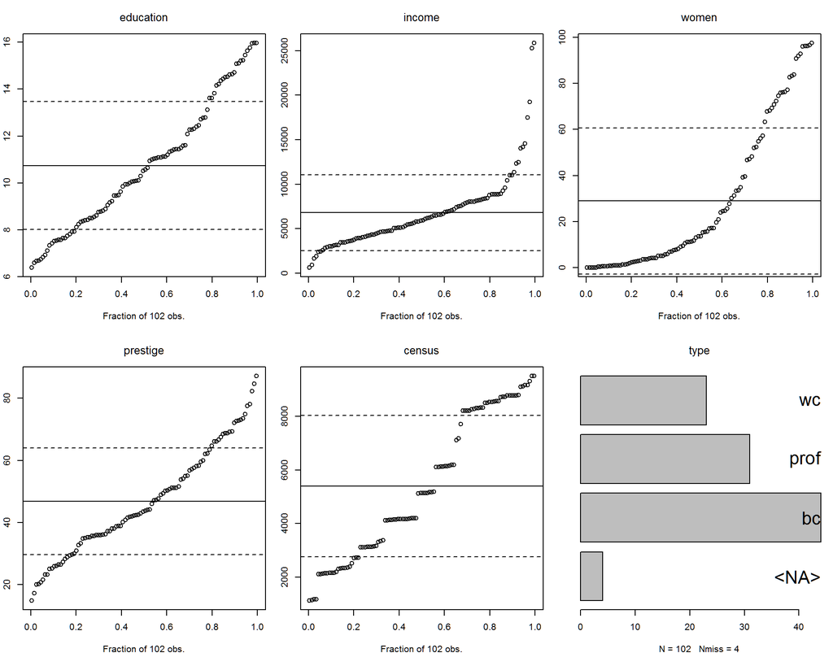

```r
xqplot(Prestige)
```

I find ‘xqplot’ invaluable for quick exploration but don’t use it for polished reports or presentations.

### Regression of income on education and gender

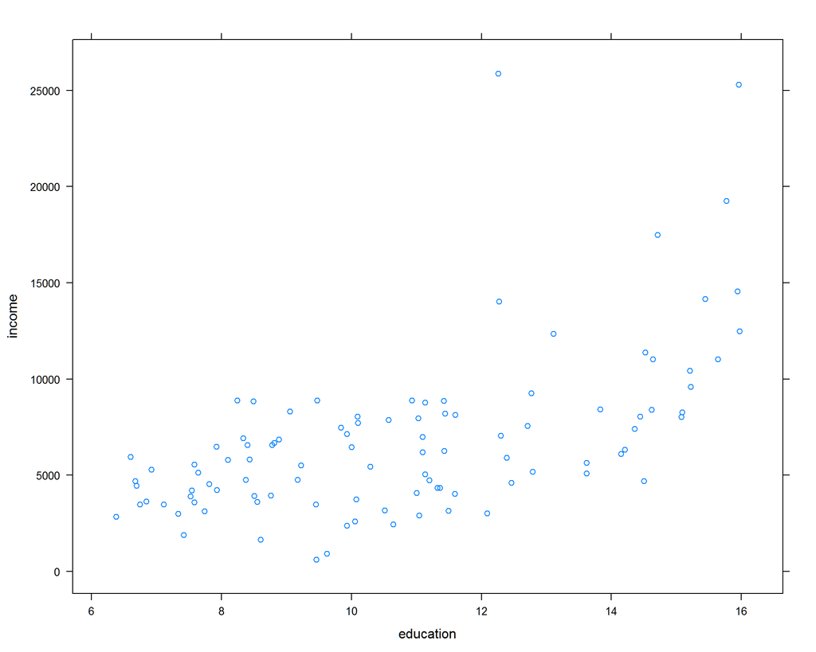

```r
xyplot( income ~ education , Prestige)
```

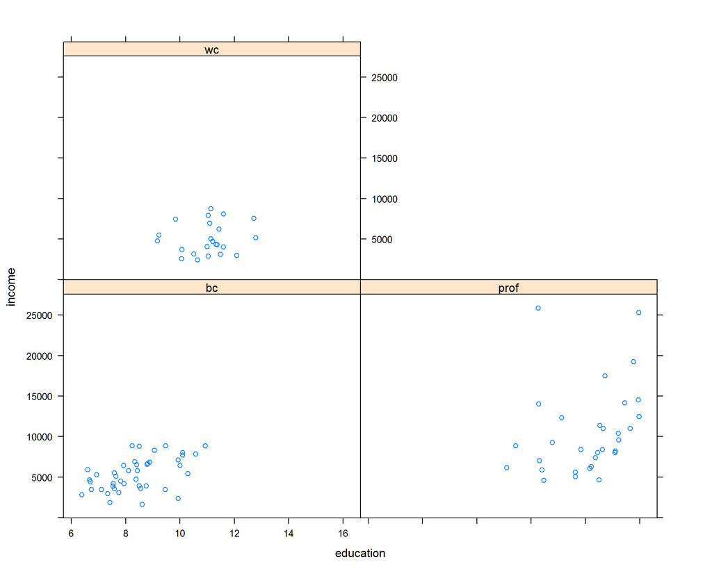

```r
xyplot( income ~ education | type, Prestige)
```

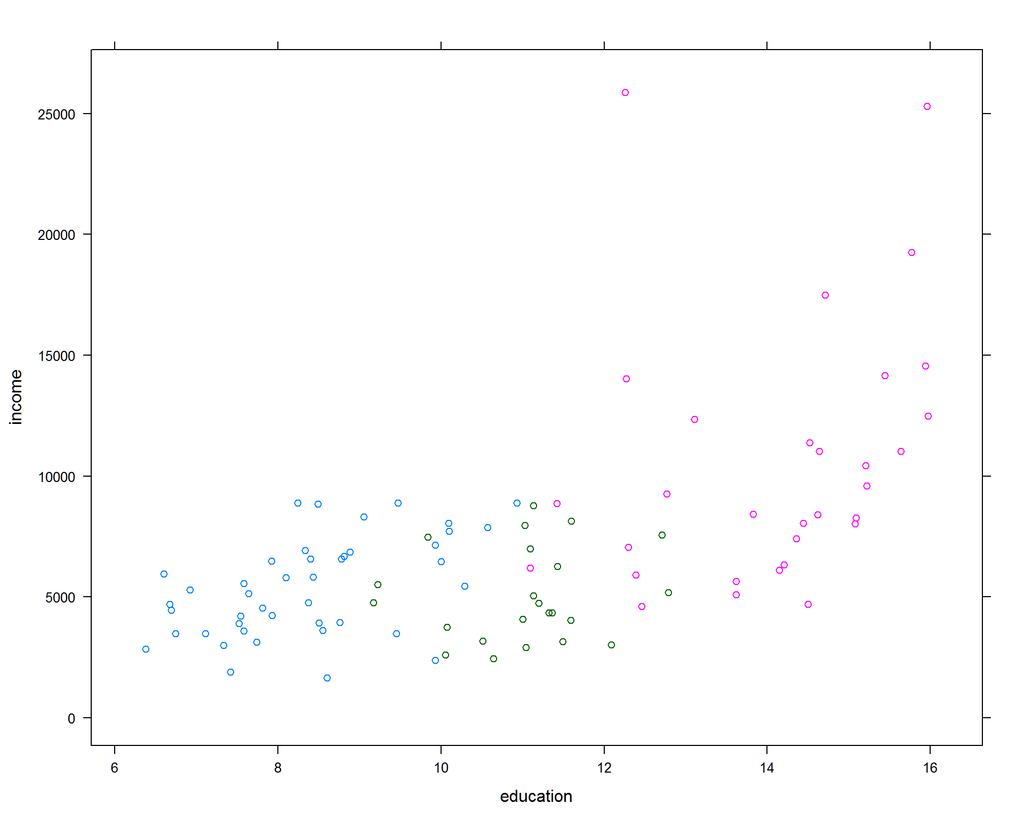

```r
xyplot( income ~ education, Prestige, groups = type)
```

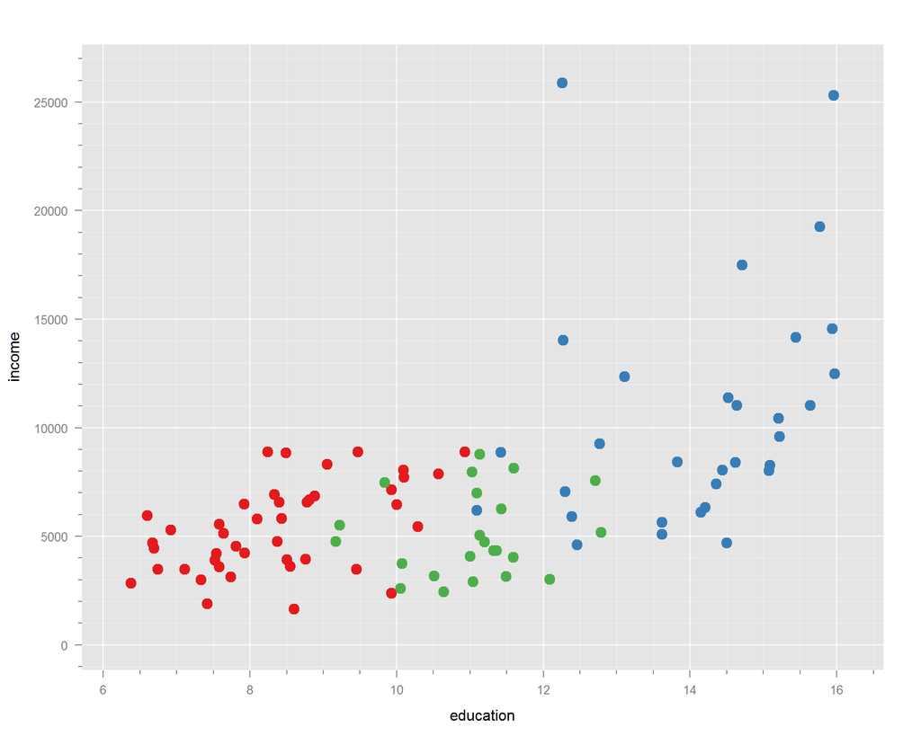

```r
gd(3) # in the spida2 package, uses a 'ggplot'-like theme for groups
xyplot( income ~ education, Prestige, groups = type)
```

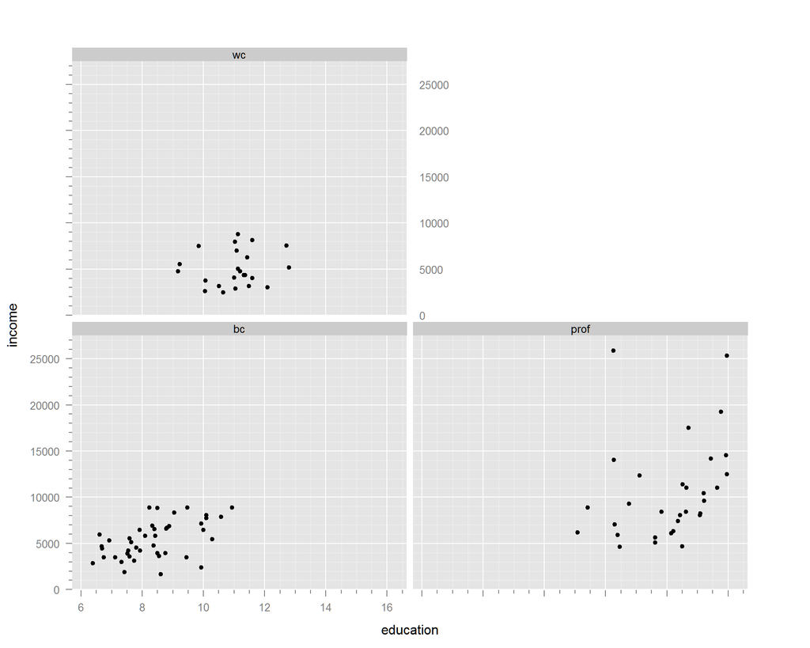

```r
xyplot( income ~ education | type, Prestige)
```

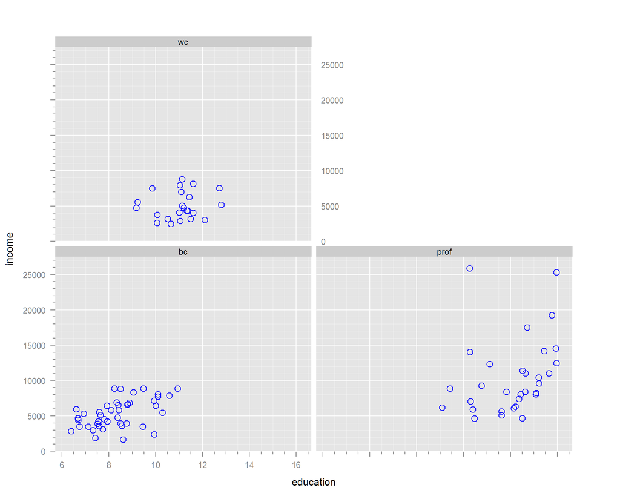

```r
# The gd and gd_ functions in spida2 make lattice plots look more like ggplot2
gd_(col = 'blue', cex = 1.2, pch = 1)  # to change options when not using groups
xyplot( income ~ education | type, Prestige)
```

The followin only works interactively, so we set eval=FALSE

```r
xyplot( income ~ education, Prestige, groups = type)
trellis.focus()
zz <- panel.identify(labels=rownames(Prestige))
zz
trellis.unfocus()
```

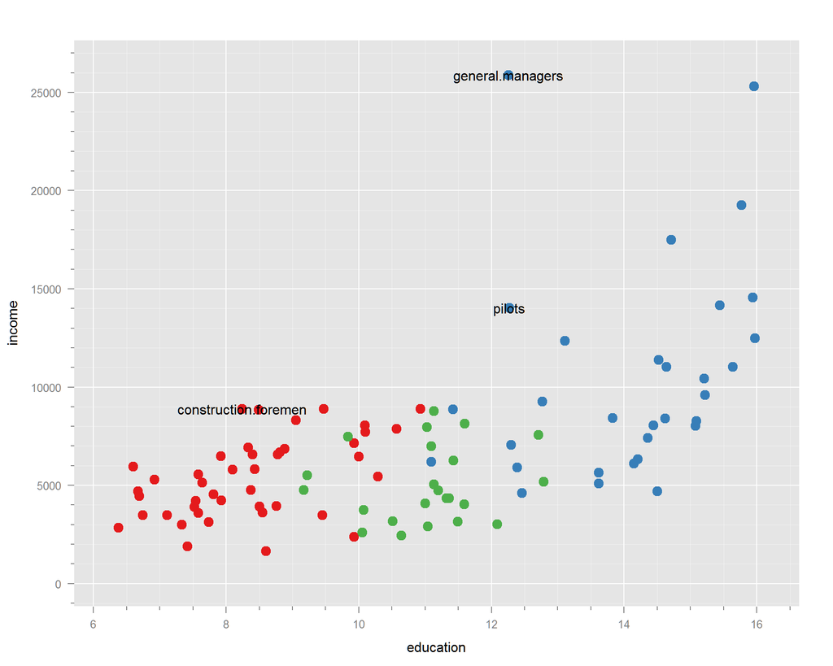

```r
zz <- c(2, 90,96)
gd_(3,cex=0.9)
xyplot( income ~ education, Prestige, groups = type,
        labels = rownames(Prestige)) +
  layer( panel.text(x=x[zz],y=y[zz], labels=labels[zz],
                    cex = 1))
```

### Regression with interation

Fitting a regression with interaction between education and type

```r
fiti <- lm(income ~ education * type, Prestige)
summary(fiti)
```

```
   Call:
   lm(formula = income ~ education * type, data = Prestige)

   Residuals:
       Min      1Q  Median      3Q     Max
   -6330.8 -1769.2  -356.8  1166.5 17326.2

   Coefficients:
                      Estimate Std. Error t value Pr(>|t|)
   (Intercept)         -1865.0     3682.3  -0.506   0.6137
   education             866.0      436.4   1.984   0.0502 .
   typeprof            -3068.4     7191.8  -0.427   0.6706
   typewc               3646.5     9274.0   0.393   0.6951
   education:typeprof    234.0      617.3   0.379   0.7055
   education:typewc     -569.2      884.8  -0.643   0.5216
   ---
   Signif. codes:  0 '***' 0.001 '**' 0.01 '*' 0.05 '.' 0.1 ' ' 1

   Residual standard error: 3333 on 92 degrees of freedom
     (4 observations deleted due to missingness)
   Multiple R-squared:  0.4105, Adjusted R-squared:  0.3785
   F-statistic: 12.81 on 5 and 92 DF,  p-value: 1.856e-09
```

Testing the interaction term:

Using likelihood ratio tests:

Type I Sums of Squares: Sequential hypotheses

```r
anova(fiti)
```

```
   Analysis of Variance Table

   Response: income
                  Df     Sum Sq   Mean Sq F value    Pr(>F)
   education       1  571532362 571532362 51.4405 1.824e-10 ***
   type            2  131170201  65585100  5.9030  0.003873 **
   education:type  2    9204946   4602473  0.4142  0.662067
   Residuals      92 1022171653  11110561
   ---
   Signif. codes:  0 '***' 0.001 '**' 0.01 '*' 0.05 '.' 0.1 ' ' 1
```

Type II Sums of Squares: Extra SS respecting Principle of Marginality

```r
library(car)
Anova(fiti)
```

```
   Anova Table (Type II tests)

   Response: income
                      Sum Sq Df F value   Pr(>F)
   education       106746406  1  9.6077 0.002571 **
   type            131170201  2  5.9030 0.003873 **
   education:type    9204946  2  0.4142 0.662067
   Residuals      1022171653 92
   ---
   Signif. codes:  0 '***' 0.001 '**' 0.01 '*' 0.05 '.' 0.1 ' ' 1
```

Type III Sums of Squares

```r
Anova(fiti, type = "III")
```

```
   Anova Table (Type III tests)

   Response: income
                      Sum Sq Df F value  Pr(>F)
   (Intercept)       2850137  1  0.2565 0.61373
   education        43755529  1  3.9382 0.05018 .
   type              4691982  2  0.2111 0.81004
   education:type    9204946  2  0.4142 0.66207
   Residuals      1022171653 92
   ---
   Signif. codes:  0 '***' 0.001 '**' 0.01 '*' 0.05 '.' 0.1 ' ' 1
```

Using Wald tests

```r
library(spida2)
```

Individual coefficients: can’t use for tests involving more than one degree of freedom

```r
wald(fiti)
```

```
    numDF denDF  F.value p.value
        6    92 81.45982 <.00001

   Coefficients           Estimate Std.Error DF   t-value p-value  Lower 0.95 Upper 0.95
     (Intercept)        -1865.0362 3682.3276 92 -0.506483 0.61373  -9178.4566   5448.384
     education            866.0004  436.3848 92  1.984488 0.05018     -0.6975   1732.698
     typeprof           -3068.3645 7191.7966 92 -0.426648 0.67063 -17351.8933  11215.164
     typewc              3646.5441 9274.0238 92  0.393200 0.69508 -14772.4676  22065.556
     education:typeprof   234.0166  617.2602 92  0.379122 0.70547   -991.9153   1459.949
     education:typewc    -569.2417  884.7820 92 -0.643369 0.52158  -2326.4951   1188.012
```

Joint test for interaction:

```r
wald(fiti,":")
```

```
     numDF denDF   F.value p.value
   :     2    92 0.4142431 0.66207

   Coefficients          Estimate Std.Error DF   t-value p-value Lower 0.95 Upper 0.95
     education:typeprof  234.0166  617.2602 92  0.379122 0.70547  -991.9153   1459.949
     education:typewc   -569.2417  884.7820 92 -0.643369 0.52158 -2326.4951   1188.012
```

Joint test for type:

```r
wald(fiti,"type")
```

```
        numDF denDF  F.value p.value
   type     4    92 3.158597 0.01761

   Coefficients           Estimate Std.Error DF   t-value p-value  Lower 0.95 Upper 0.95
     typeprof           -3068.3645 7191.7966 92 -0.426648 0.67063 -17351.8933  11215.164
     typewc              3646.5441 9274.0238 92  0.393200 0.69508 -14772.4676  22065.556
     education:typeprof   234.0166  617.2602 92  0.379122 0.70547   -991.9153   1459.949
     education:typewc    -569.2417  884.7820 92 -0.643369 0.52158  -2326.4951   1188.012
```

Joint test for education:

```r
wald(fiti,"education")
```

```
             numDF denDF  F.value p.value
   education     3    92 3.478713  0.0191

   Coefficients          Estimate Std.Error DF   t-value p-value Lower 0.95 Upper 0.95
     education           866.0004  436.3848 92  1.984488 0.05018    -0.6975   1732.698
     education:typeprof  234.0166  617.2602 92  0.379122 0.70547  -991.9153   1459.949
     education:typewc   -569.2417  884.7820 92 -0.643369 0.52158 -2326.4951   1188.012
```

Visualizing the fitted model

```r
pred <- Prestige
pred <- cbind(pred, predict(fiti, newdata = pred, se = T))
head(pred)
```

```
                       education income women prestige census type       fit    se.fit df
   gov.administrators      13.11  12351 11.16     68.8   1113 prof  9487.822  734.3529 92
   general.managers        12.26  25879  4.02     69.1   1130 prof  8552.808  996.2879 92
   accountants             12.77   9271 15.70     63.4   1171 prof  9113.816  829.1888 92
   purchasing.officers     11.42   8865  9.11     56.8   1175 prof  7628.793 1308.0967 92
   chemists                14.62   8403 11.68     73.5   2111 prof 11148.848  642.7426 92
   physicists              15.64  11030  5.13     77.6   2113 prof 12270.865  905.3766 92
                       residual.scale
   gov.administrators        3333.251
   general.managers          3333.251
   accountants               3333.251
   purchasing.officers       3333.251
   chemists                  3333.251
   physicists                3333.251
```

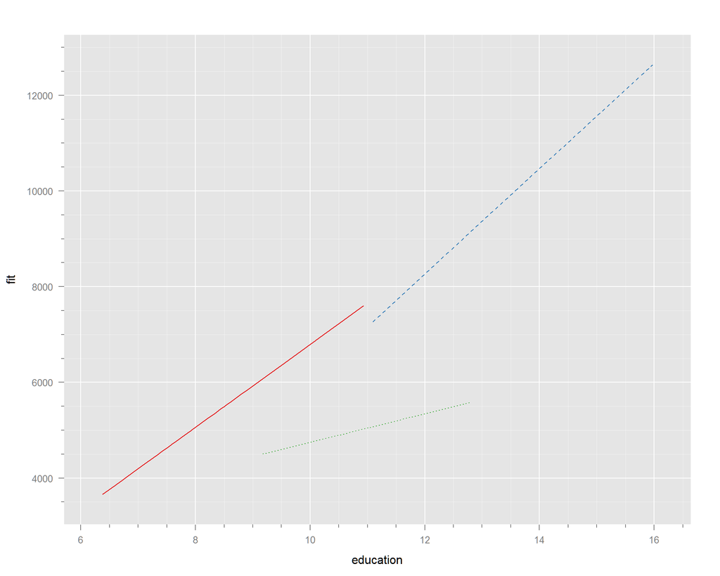

```r
pred <- sortdf(pred, ~ education)
xyplot(fit ~ education, pred,
       groups = type,
       type = 'l')
```

Adding uncertainty:

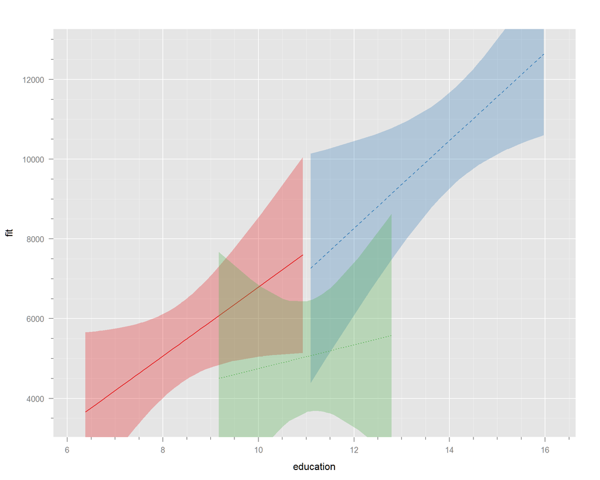

```r
library(latticeExtra)
library(spida2)
xyplot(fit ~ education, pred,
       groups = type,
       type = 'n',
       fit = pred$fit,
       upper = pred$fit + 2*pred$se.fit,
       lower = pred$fit - 2*pred$se.fit,
       subscripts = TRUE) +
  glayer(panel.fit(...))
```

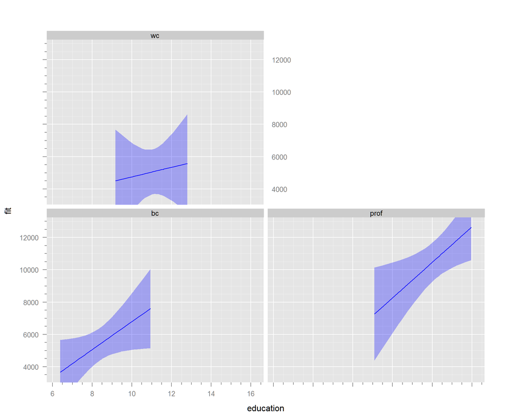

```r
# in panels
xyplot(fit ~ education | type, pred,
       type = 'n',
       fit = pred$fit,
       upper = pred$fit + 2*pred$se.fit,
       lower = pred$fit - 2*pred$se.fit,
       subscripts = TRUE) +
  layer(panel.fit(...))
```

In 3d:

```r
library(p3d) # devtools::install_github('gmonette/p3d')
Init3d()
Plot3d(income ~ education + women | type, Prestige)
fg()
Id3d()
```

Fitting a regression:

```r
fit <- lm(income ~ education + women, Prestige)
summary(fit)
```

```
   Call:
   lm(formula = income ~ education + women, data = Prestige)

   Residuals:
       Min      1Q  Median      3Q     Max
   -7257.6 -1160.1  -238.6   681.1 16044.3

   Coefficients:
                Estimate Std. Error t value Pr(>|t|)
   (Intercept) -1491.998   1162.299  -1.284    0.202
   education     944.881    103.731   9.109 9.60e-15 ***
   women         -64.056      8.921  -7.180 1.31e-10 ***
   ---
   Signif. codes:  0 '***' 0.001 '**' 0.01 '*' 0.05 '.' 0.1 ' ' 1

   Residual standard error: 2839 on 99 degrees of freedom
   Multiple R-squared:  0.5618, Adjusted R-squared:  0.5529
   F-statistic: 63.46 on 2 and 99 DF,  p-value: < 2.2e-16
```

### Regression diagnostics

Standard diagnostics for linear models:

1. ressiduals vs yhat: look for heteroscedasticity, non-linearity
2. normal quantile plot of residuals: look for gaps, clusters, kurtosis, skewness
3. square root of absolute residual versus yhat: fitted line can show heteroscedasticity
4. residual vs leverage (~ Mahalanobis distance in predictor space): great to identify type 1, 2 and 3 outliers and to help see their potential impact on regression. Note:
   - Type 1: in upper or lower left: Increases width of CIs, increases p-values
   - Type 2: in middle right: Shrinks CIs, shrinks p-values
   - Type 3: in upper of lower right: affects $\beta$s, indeterminate impact on width of CIs, p-values

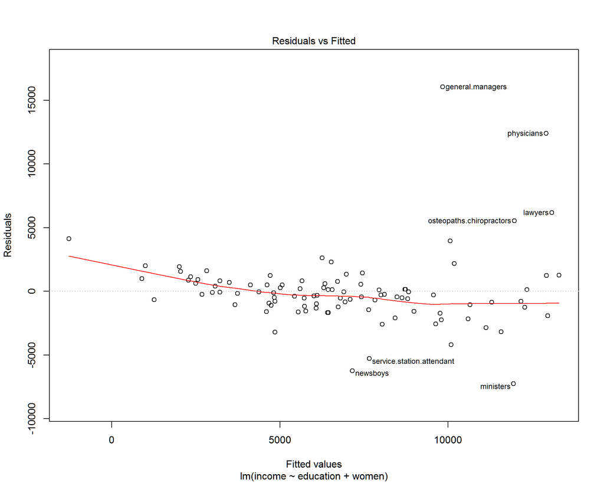

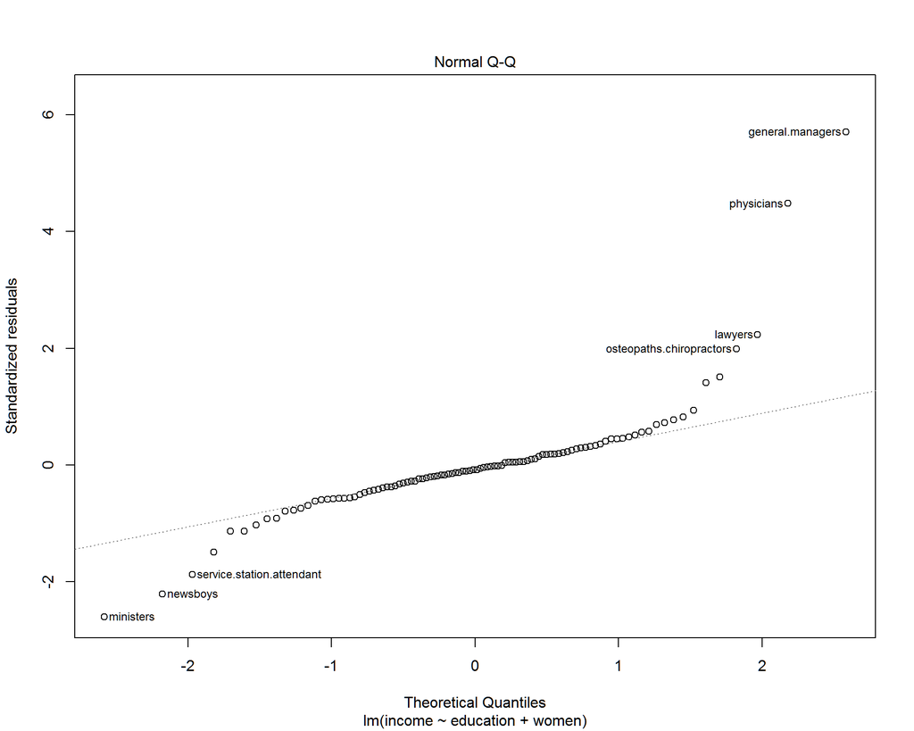

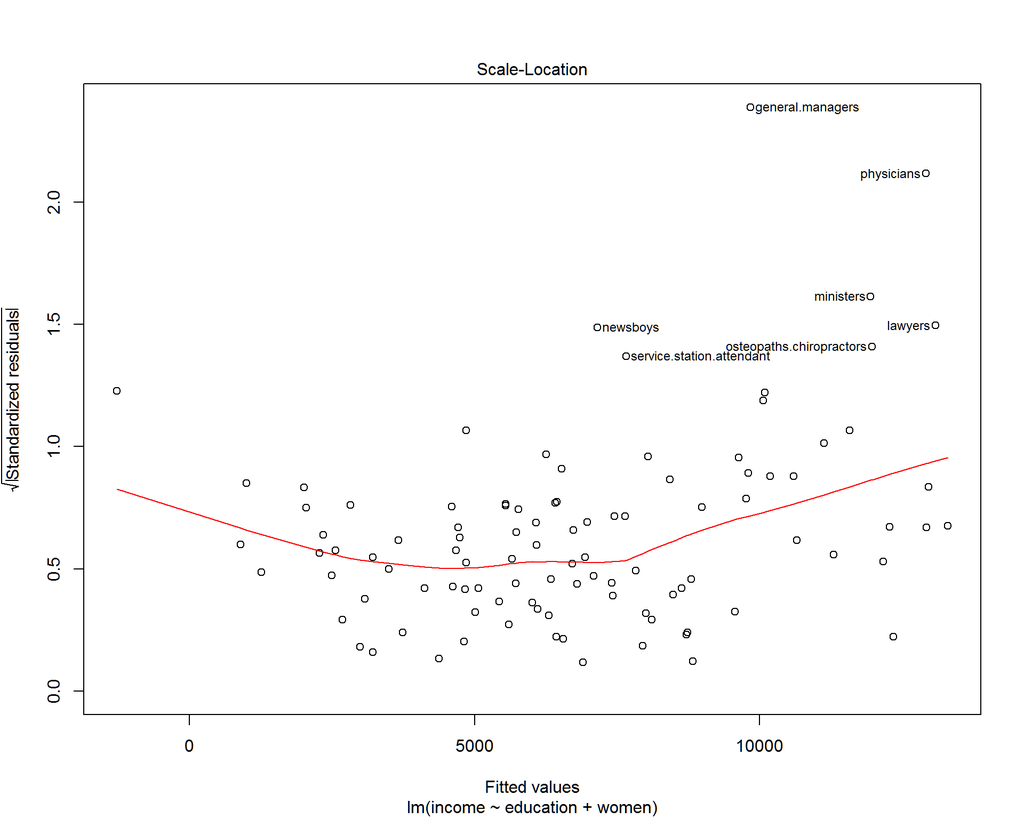

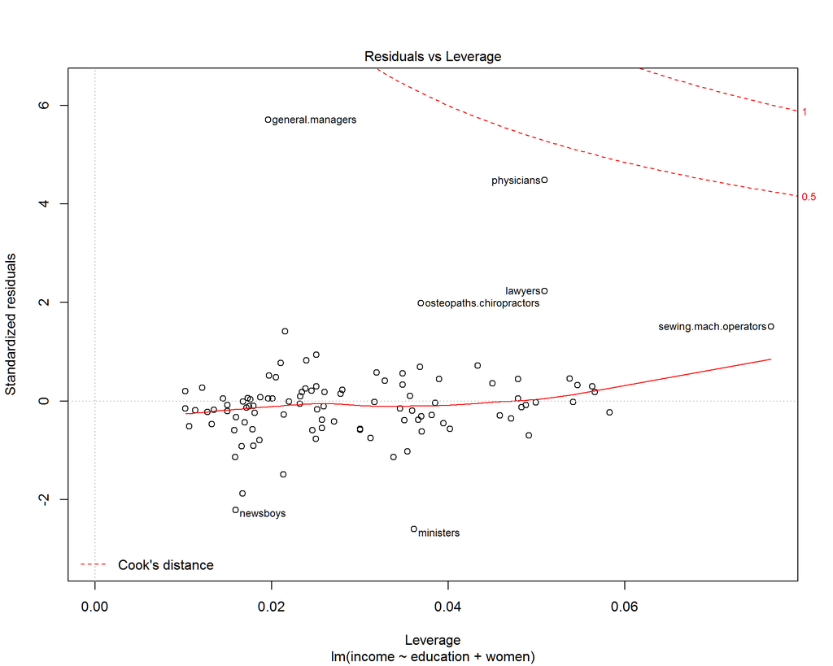

```r
plot(fit, id.n = 7)  # id.n is the number to identify
```

Added-variable plots: ideal to view leverage and influence on individual coefficients

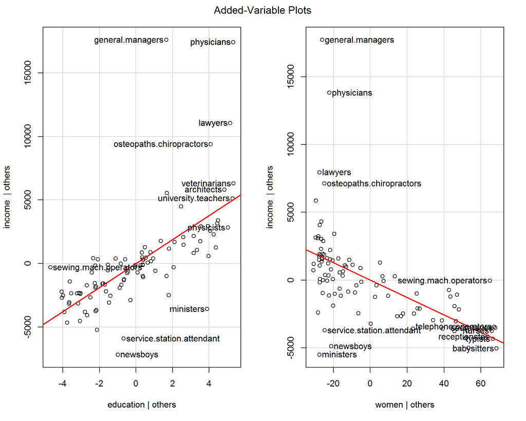

```r
avPlots(fit, id.n = 7)
```

## Exploring expected income

We explore expected income as a function of gender, education and type of occupation

```r
fit <- lm( income ~ education * women * type, Prestige)
```

One of my favourite exam questions is to display output like this and ask “what is exact interpretation of the coefficient labelled ‘women’? the coefficient labelled ‘typewc’? etc.

```r
summary(fit)
```

```
   Call:
   lm(formula = income ~ education * women * type, data = Prestige)

   Residuals:
       Min      1Q  Median      3Q     Max
   -8463.8  -896.2    43.5   676.3 15251.9

   Coefficients:
                             Estimate Std. Error t value Pr(>|t|)
   (Intercept)                429.394   3895.702   0.110    0.912
   education                  685.790    449.824   1.525    0.131
   women                       15.796    120.522   0.131    0.896
   typeprof                 -4207.863   7813.683  -0.539    0.592
   typewc                   -1855.557  11620.343  -0.160    0.874
   education:women             -7.278     14.975  -0.486    0.628
   education:typeprof         512.663    660.676   0.776    0.440
   education:typewc           167.310   1105.903   0.151    0.880
   women:typeprof             115.282    298.739   0.386    0.701
   women:typewc               -57.791    262.005  -0.221    0.826
   education:women:typeprof    -9.247     24.993  -0.370    0.712
   education:women:typewc       6.081     25.740   0.236    0.814

   Residual standard error: 2825 on 86 degrees of freedom
     (4 observations deleted due to missingness)
   Multiple R-squared:  0.6043, Adjusted R-squared:  0.5537
   F-statistic: 11.94 on 11 and 86 DF,  p-value: 3.055e-13
```

Some diagnostics:

Looking at residuals is an opportunity to think of factors that might have been omitted in the model. Is there a clump of residuals with a common attribute?

Does the model look reasonable? What should we look for?

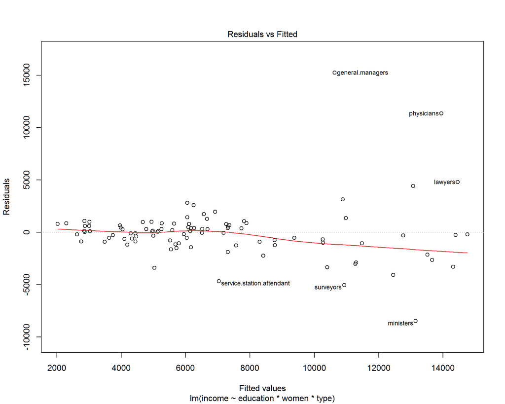

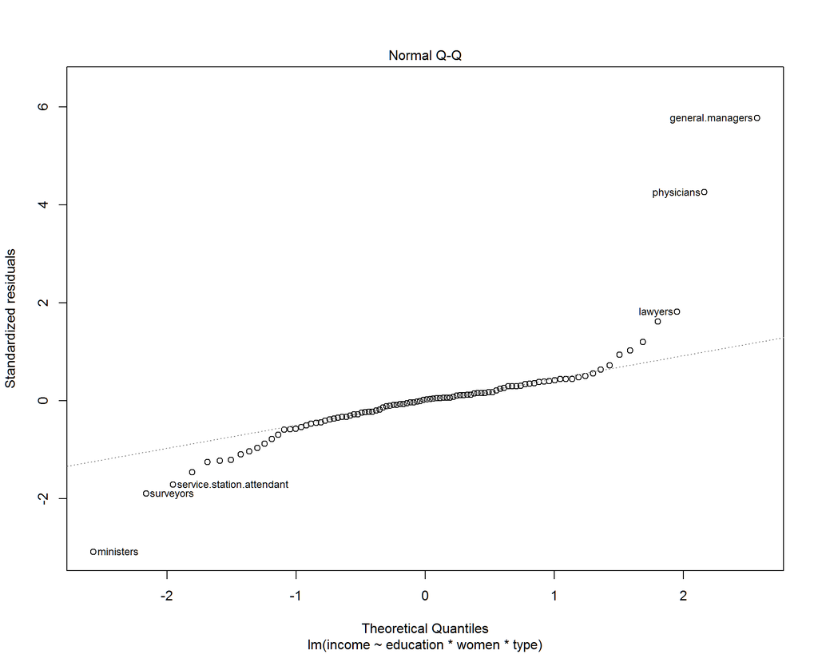

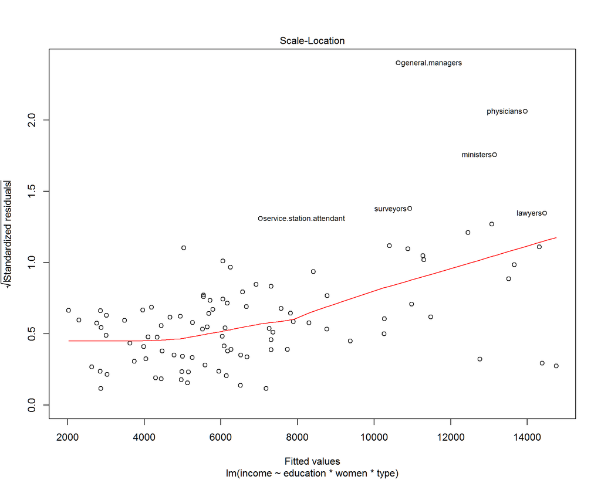

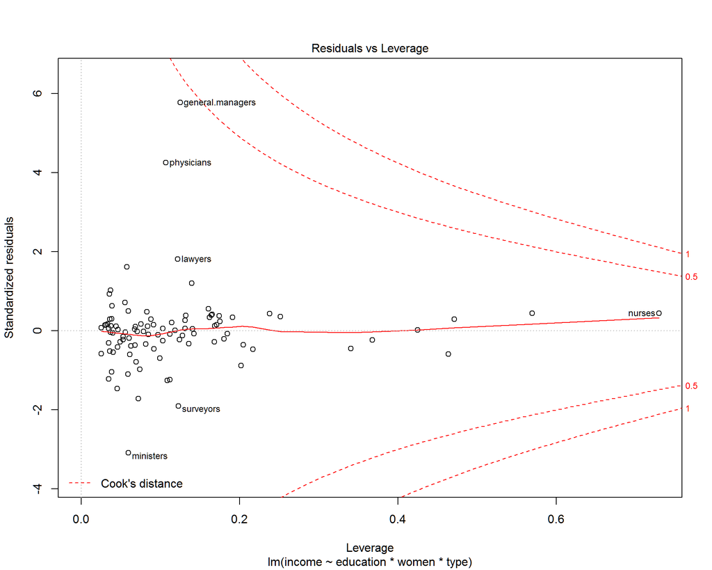

```r
plot(fit, id.n = 6)
```

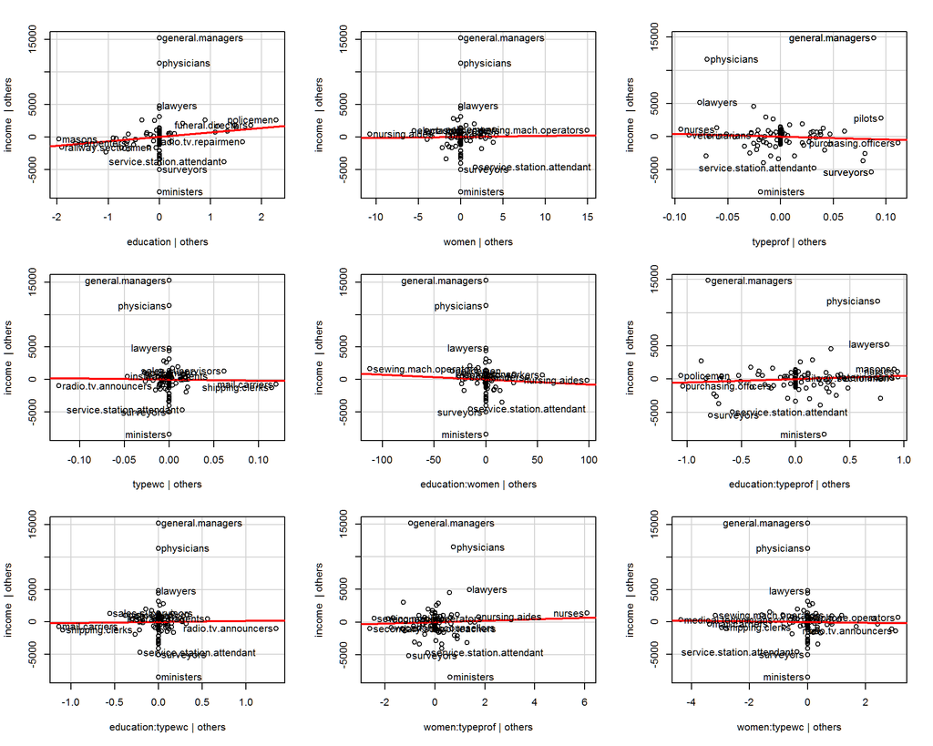

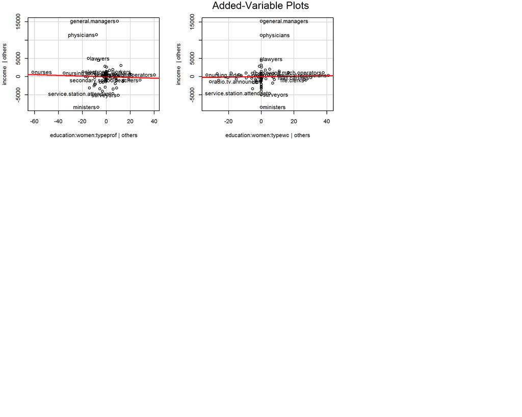

```r
avPlots(fit, id.n = 6)
```

### Looking at the model in 3d

```r
library(p3d)
Init3d()
Plot3d(income ~ education + women | type, Prestige,
       col = c('blue','green','orange'))
Axes3d()
Id3d()
Fit3d(fit)
fitq <- update(fit,
        . ~ type * (education * women +
                      I(education^2) + I(women^2)))
Pop3d(6)
Fit3d(fitq) # shows how quads don't extrapolate here
```

Questions:

1. How many parameters do we have?
2. How many observations?
3. Is the ratio reasonable?
4. How should we handle the large standard deviation of residuals at the higher levels of predicted incomes?
- transform the response? e.g. log(income) which would allow us to estimate the proportional ‘effect’ of a change in x.
- modify the model so it adapts to heteroscedasticity.
5. Should we simplify the model?

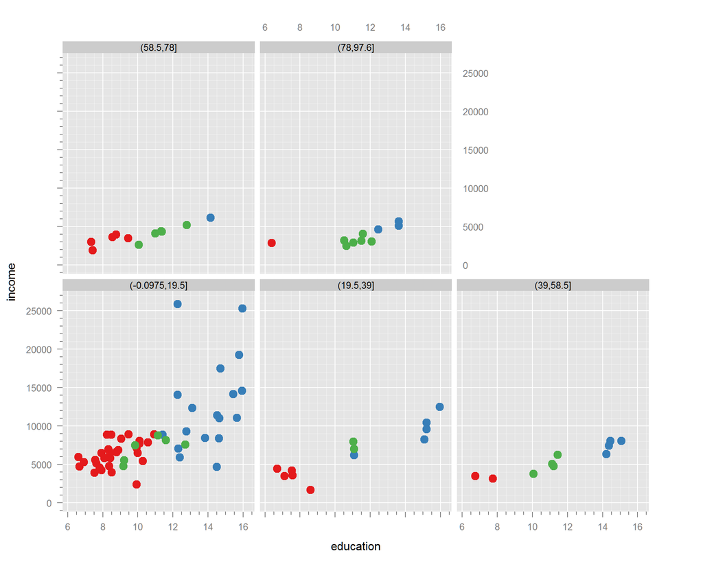

```r
xyplot( income ~ education | cut(women,5), Prestige, groups = type)
```

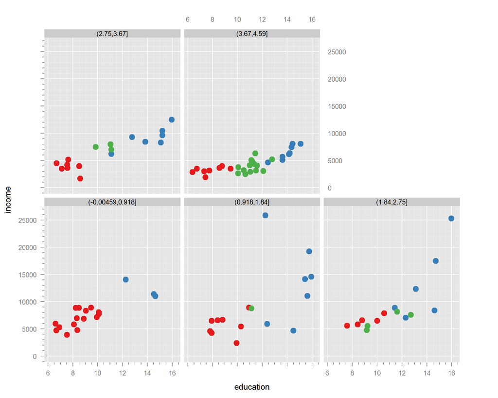

```r
# we get a more even distribution with cut by using a transformation of a more uniformly distributed variable
xyplot( income ~ education | cut(log(women+1),5), Prestige, groups = type)
```

The following commands will look very complex but there’s a logic behind them. ‘Base graphics’ are much easier to add to but they don’t have panels. ‘Lattice graphics’ are much nicer in many ways but it is much more difficult to add overlays. The way I do things here, with ‘latticeExtra’ is a bit old-fashioned.

The trendy way is to use ‘ggplot2’ but I’m waiting for the next great thing to mature. My bets are on ‘ggvis’ by Winston Chang to which I plan to convert as soon as they decide to include panels (also called ‘facets’).

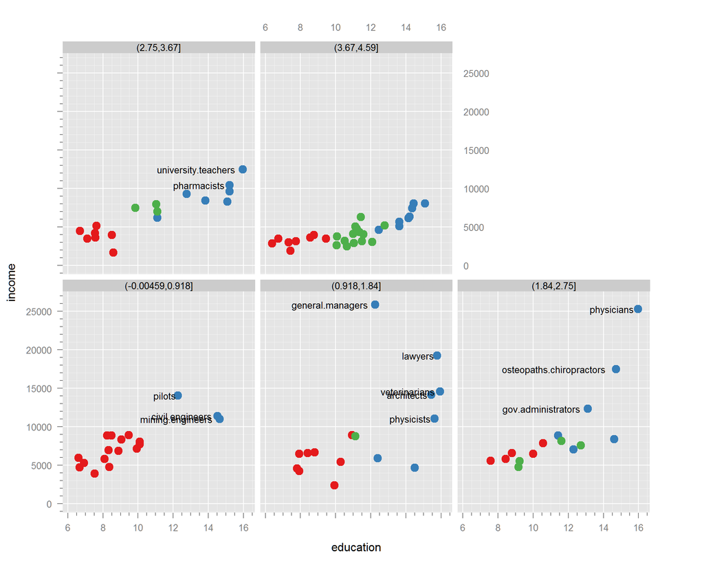

```r
xyplot( income ~ education | cut(log(women+1),5),
        Prestige,
        groups = type,
        occ = rownames(Prestige)) +
  glayer({ok <- (y > 10000); panel.text(x[ok],y[ok],occ[subscripts][ok],adj=1.1)})
```

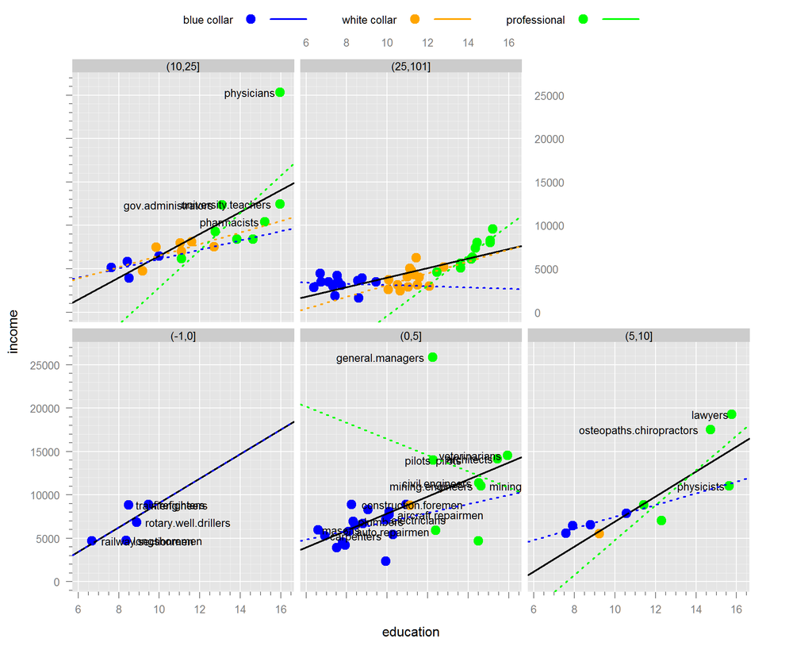

```r
Prestige$Type <- tr(Prestige$type,c("bc","wc","prof"),c('blue collar','white collar','professional'))
Prestige$Type <- with(Prestige, reorder(Type, education))
gd(col = c('blue','orange','green'), lwd = 2, lty = 1)
xyplot( income ~ education | cut(women,c(-1,0,5,10,25,101)),
        Prestige,
        groups = Type, subscripts = TRUE,
        occ = rownames(Prestige),
        women = Prestige$women,
        auto.key = list(columns = 3, lines = T)) +
  glayer({ok <- (y > 10000); panel.text(x[ok], y[ok], occ[subscripts][ok], adj=1.1)}) +
  glayer({ok <- (women[subscripts] < 1); panel.text(x[ok],y[ok],occ[subscripts][ok], adj=-0.1)}) +
  layer(panel.lmline(..., lwd = 2))+
  glayer(panel.lmline(..., col = 'blue', lty=3))
```

## Using Generalized Least Squares

We will use the ‘gls’ (generalized least-squares) function in the ‘nlme’ package to incorporate heteroscedasticity in the model.

```r
library(nlme)
```

```r
?gls
```

```r
Prestige$occ <- rownames(Prestige)   # make the rownames a variable
fit <- gls(income ~ education * women * type, Prestige, na.action = na.omit)
summary(fit)
```

```
   Generalized least squares fit by REML
     Model: income ~ education * women * type
     Data: Prestige
          AIC      BIC    logLik
     1718.701 1750.608 -846.3507

   Coefficients:
                                Value Std.Error    t-value p-value
   (Intercept)                429.394  3895.702  0.1102226  0.9125
   education                  685.790   449.824  1.5245735  0.1310
   women                       15.796   120.522  0.1310627  0.8960
   typeprof                 -4207.863  7813.683 -0.5385249  0.5916
   typewc                   -1855.557 11620.343 -0.1596817  0.8735
   education:women             -7.278    14.975 -0.4859851  0.6282
   education:typeprof         512.663   660.676  0.7759666  0.4399
   education:typewc           167.310  1105.903  0.1512882  0.8801
   women:typeprof             115.282   298.739  0.3858964  0.7005
   women:typewc               -57.791   262.005 -0.2205732  0.8259
   education:women:typeprof    -9.247    24.993 -0.3699850  0.7123
   education:women:typewc       6.081    25.740  0.2362527  0.8138

    Correlation:
                            (Intr) eductn women  typprf typewc edctn:w edctn:typp edctn:typw
   education                -0.991
   women                    -0.536  0.537
   typeprof                 -0.499  0.494  0.267
   typewc                   -0.335  0.332  0.180  0.167
   education:women           0.493 -0.504 -0.990 -0.246 -0.165
   education:typeprof        0.675 -0.681 -0.365 -0.968 -0.226  0.343
   education:typewc          0.403 -0.407 -0.218 -0.201 -0.991  0.205   0.277
   women:typeprof            0.216 -0.217 -0.403 -0.606 -0.073  0.399   0.579      0.088
   women:typewc              0.247 -0.247 -0.460 -0.123 -0.700  0.455   0.168      0.690
   education:women:typeprof -0.295  0.302  0.593  0.578  0.099 -0.599  -0.582     -0.123
   education:women:typewc   -0.287  0.293  0.576  0.143  0.669 -0.582  -0.200     -0.672
                            wmn:typp wmn:typw edctn:wmn:typp
   education
   women
   typeprof
   typewc
   education:women
   education:typeprof
   education:typewc
   women:typeprof
   women:typewc              0.186
   education:women:typeprof -0.970   -0.273
   education:women:typewc   -0.232   -0.985    0.349

   Standardized residuals:
           Min          Q1         Med          Q3         Max
   -2.99630314 -0.31726257  0.01540937  0.23943778  5.39940549

   Residual standard error: 2824.742
   Degrees of freedom: 98 total; 86 residual
```

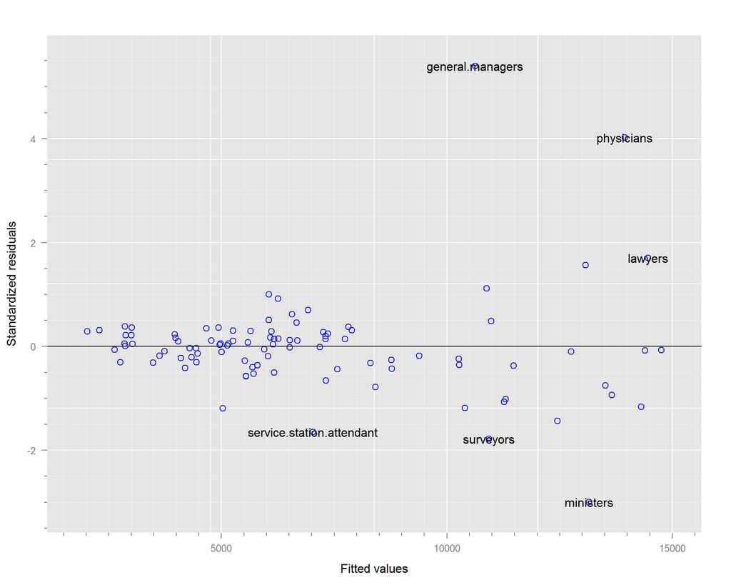

```r
plot(fit, id = .1, idLabels = ~ occ)  # default not as much as with 'lm' but fit should be the same
```

```r
#       - note how we use 'id' = proportion to identify
#         instead of 'id.n' = number to identify
#       - also the 'idLabels' are given with a formula
```

There is heteroscedascity and we should do something to take into account the much larger variance when the fitted value is large.

Depending on circumstances, this could be addressed in many ways some of which are:

1. Perhaps the large residuals are anomalous or consequences of a process not included in the model. They could be segregated or the model enlarged to predict their value.
2. Perhaps the natural model should be based on a transformation of the response or of the predictors.  
   A transformation will sometimes restore linearity and homoscedasticity.  
   Find a good reference on Tukey’s ladder of powers.  
   But don’t transform mechanically. If the relationship is not linear, often you want to use a model that is not linear in the predictors, or even not linear in the parameters.
3. Perhaps it makes sense to have larger variance at higher predicted values and the model should incorporate a term to allow for heteroscedasticity. This is what we pursue below with ‘gls’ in the ‘nlme’ package.

```r
fit2 <- gls(income ~ education * women * type, Prestige,
            weights = varPower(form = ~fitted(.)),
            na.action = na.omit,
            method = "ML")
summary(fit2)
```

```
   Generalized least squares fit by maximum likelihood
     Model: income ~ education * women * type
     Data: Prestige
          AIC      BIC    logLik
     1747.071 1783.261 -859.5356

   Variance function:
    Structure: Power of variance covariate
    Formula: ~fitted(.)
    Parameter estimates:
      power
   1.683904

   Coefficients:
                                 Value Std.Error    t-value p-value
   (Intercept)               -264.1220  1897.000 -0.1392314  0.8896
   education                  745.3383   236.266  3.1546578  0.0022
   women                       27.0661    29.097  0.9301896  0.3549
   typeprof                 -1526.6728  9566.468 -0.1595858  0.8736
   typewc                   -2866.3324  6270.882 -0.4570860  0.6488
   education:women             -7.7406     3.734 -2.0730000  0.0412
   education:typeprof         281.4594   733.592  0.3836727  0.7022
   education:typewc           213.1360   621.081  0.3431694  0.7323
   women:typeprof              81.6155   185.732  0.4394265  0.6615
   women:typewc               -46.0244    89.710 -0.5130341  0.6092
   education:women:typeprof    -6.3530    14.453 -0.4395745  0.6613
   education:women:typewc       5.2256     8.831  0.5917146  0.5556

    Correlation:
                            (Intr) eductn women  typprf typewc edctn:w edctn:typp edctn:typw
   education                -0.991
   women                    -0.817  0.816
   typeprof                 -0.198  0.197  0.162
   typewc                   -0.303  0.300  0.247  0.060
   education:women           0.787 -0.802 -0.988 -0.156 -0.238
   education:typeprof        0.319 -0.322 -0.263 -0.985 -0.097  0.258
   education:typewc          0.377 -0.380 -0.310 -0.075 -0.992  0.305   0.123
   women:typeprof            0.128 -0.128 -0.157 -0.741 -0.039  0.155   0.751      0.049
   women:typewc              0.265 -0.265 -0.324 -0.053 -0.875  0.321   0.085      0.865
   education:women:typeprof -0.203  0.207  0.255  0.724  0.062 -0.258  -0.753     -0.079
   education:women:typewc   -0.333  0.339  0.418  0.066  0.869 -0.423  -0.109     -0.875
                            wmn:typp wmn:typw edctn:wmn:typp
   education
   women
   typeprof
   typewc
   education:women
   education:typeprof
   education:typewc
   women:typeprof
   women:typewc              0.051
   education:women:typeprof -0.991   -0.083
   education:women:typewc   -0.065   -0.990    0.109

   Standardized residuals:
           Min          Q1         Med          Q3         Max
   -3.09149208 -0.50878935  0.03410532  0.42259863  4.04717365

   Residual standard error: 0.0006376203
   Degrees of freedom: 98 total; 86 residual
```

```r
wald(fit2, "women")
```

```
         numDF denDF  F.value p.value
   women     6    86 20.92152 <.00001

   Coefficients                 Estimate  Std.Error DF   t-value p-value Lower 0.95
     women                     27.066051  29.097348 86  0.930190 0.35488  -30.77756
     education:women           -7.740587   3.734003 86 -2.073000 0.04117  -15.16354
     women:typeprof            81.615462 185.731767 86  0.439427 0.66145 -287.60707
     women:typewc             -46.024438  89.710282 86 -0.513034 0.60924 -224.36258
     education:women:typeprof  -6.352953  14.452505 86 -0.439574 0.66135  -35.08358
     education:women:typewc     5.225613   8.831306 86  0.591715 0.55559  -12.33044

   Coefficients               Upper 0.95
     women                     84.909664
     education:women           -0.317636
     women:typeprof           450.837995
     women:typewc             132.313701
     education:women:typeprof  22.377677
     education:women:typewc    22.781669
```

```r
# refit with only education
fit2e <- gls(income ~ education , Prestige,
            weights = varPower(form = ~fitted(.)),
            na.action = na.omit,
            method = "ML")
summary(fit2e)
```

```
   Generalized least squares fit by maximum likelihood
     Model: income ~ education
     Data: Prestige
          AIC      BIC    logLik
     1919.512 1930.012 -955.7561

   Variance function:
    Structure: Power of variance covariate
    Formula: ~fitted(.)
    Parameter estimates:
      power
   1.878493

   Coefficients:
                   Value Std.Error   t-value p-value
   (Intercept) -466.1956 1007.1564 -0.462883  0.6445
   education    658.0577  116.0104  5.672403  0.0000

    Correlation:
             (Intr)
   education -0.975

   Standardized residuals:
          Min         Q1        Med         Q3        Max
   -2.1850181 -0.6501908 -0.1061467  0.5756162  4.6053911

   Residual standard error: 0.0002034215
   Degrees of freedom: 102 total; 100 residual
```

```r
# anova(fit2, fit2e) # should give LRT (likelihood ratio test) but it
#          doesn't because the models have
#          different y's due to missing 'type's
```

Wald test to test the hypothesis that all coefficients except the intercept and the ‘main effect’ of education can be set to 0

```r
length(coef(fit2))
```

```
   [1] 12
```

```r
wald(fit2,3:12)
```

```
     numDF denDF  F.value p.value
   1    10    86 17.93914 <.00001

                                  Estimate   Std.Error DF   t-value p-value   Lower 0.95
     women                       27.066051   29.097348 86  0.930190 0.35488    -30.77756
     typeprof                 -1526.672842 9566.468255 86 -0.159586 0.87358 -20544.18232
     typewc                   -2866.332398 6270.881525 86 -0.457086 0.64876 -15332.43229
     education:women             -7.740587    3.734003 86 -2.073000 0.04117    -15.16354
     education:typeprof         281.459354  733.592328 86  0.383673 0.70217  -1176.87393
     education:typewc           213.135959  621.080938 86  0.343169 0.73231  -1021.53208
     women:typeprof              81.615462  185.731767 86  0.439427 0.66145   -287.60707
     women:typewc               -46.024438   89.710282 86 -0.513034 0.60924   -224.36258
     education:women:typeprof    -6.352953   14.452505 86 -0.439574 0.66135    -35.08358
     education:women:typewc       5.225613    8.831306 86  0.591715 0.55559    -12.33044

                                Upper 0.95
     women                       84.909664
     typeprof                 17490.836635
     typewc                    9599.767489
     education:women             -0.317636
     education:typeprof        1739.792635
     education:typewc          1447.804000
     women:typeprof             450.837995
     women:typewc               132.313701
     education:women:typeprof    22.377677
     education:women:typewc      22.781669
```

```r
wald(fit2,'women') # uses regular expression to select terms to test
```

```
         numDF denDF  F.value p.value
   women     6    86 20.92152 <.00001

   Coefficients                 Estimate  Std.Error DF   t-value p-value Lower 0.95
     women                     27.066051  29.097348 86  0.930190 0.35488  -30.77756
     education:women           -7.740587   3.734003 86 -2.073000 0.04117  -15.16354
     women:typeprof            81.615462 185.731767 86  0.439427 0.66145 -287.60707
     women:typewc             -46.024438  89.710282 86 -0.513034 0.60924 -224.36258
     education:women:typeprof  -6.352953  14.452505 86 -0.439574 0.66135  -35.08358
     education:women:typewc     5.225613   8.831306 86  0.591715 0.55559  -12.33044

   Coefficients               Upper 0.95
     women                     84.909664
     education:women           -0.317636
     women:typeprof           450.837995
     women:typewc             132.313701
     education:women:typeprof  22.377677
     education:women:typewc    22.781669
```

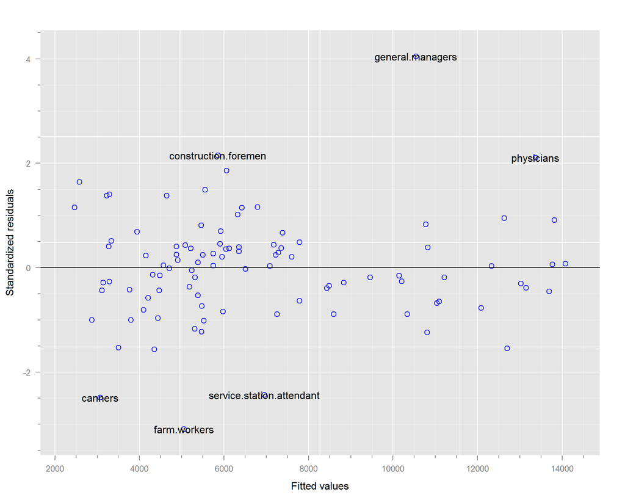

```r
plot(fit2, id = .05, idLabels = ~ occ) # standardized residuals divided by estimated standard deviation
```

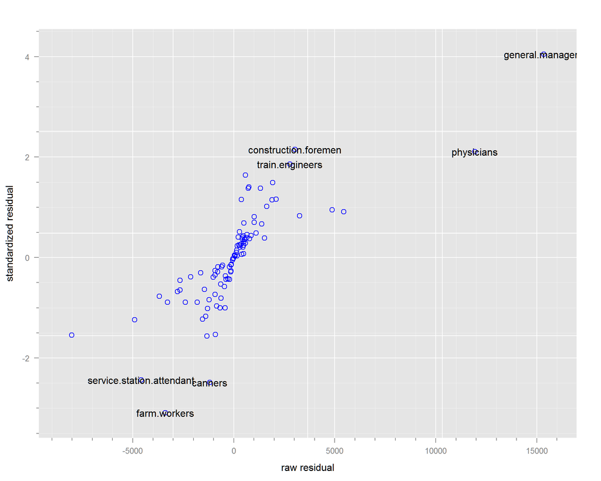

```r
plot(fit2, resid(., type = 'p') ~ resid(., type = 'response'),
     xlab = 'raw residual',
     ylab = 'standardized residual',
     id = .1, idLabels = ~ occ)
```

Let’s ask whether we can consider simplifying the model by dropping the 3-way interaction

```r
wald(fit2, ':.*:' ) # we use a regular expression that matches terms
```

```
        numDF denDF   F.value p.value
   :.*:     2    86 0.3037139 0.73886

   Coefficients                Estimate Std.Error DF   t-value p-value Lower 0.95 Upper 0.95
     education:women:typeprof -6.352953 14.452505 86 -0.439574 0.66135  -35.08358   22.37768
     education:women:typewc    5.225613  8.831306 86  0.591715 0.55559  -12.33044   22.78167
```

```r
#           with two or more ':'s, i.e. 3- and higher-way interactions
wald(fit2, ':' ) # we use a regular expression that matches
```

```
     numDF denDF  F.value p.value
   :     7    86 2.439493 0.02495

   Coefficients                 Estimate  Std.Error DF   t-value p-value  Lower 0.95
     education:women           -7.740587   3.734003 86 -2.073000 0.04117   -15.16354
     education:typeprof       281.459354 733.592328 86  0.383673 0.70217 -1176.87393
     education:typewc         213.135959 621.080938 86  0.343169 0.73231 -1021.53208
     women:typeprof            81.615462 185.731767 86  0.439427 0.66145  -287.60707
     women:typewc             -46.024438  89.710282 86 -0.513034 0.60924  -224.36258
     education:women:typeprof  -6.352953  14.452505 86 -0.439574 0.66135   -35.08358
     education:women:typewc     5.225613   8.831306 86  0.591715 0.55559   -12.33044

   Coefficients                Upper 0.95
     education:women            -0.317636
     education:typeprof       1739.792635
     education:typewc         1447.804000
     women:typeprof            450.837995
     women:typewc              132.313701
     education:women:typeprof   22.377677
     education:women:typewc     22.781669
```

```r
#                all interactions
# or more ':'s
wald(fit2, 'type')  # does type add to other variables?
```

```
        numDF denDF  F.value p.value
   type     8    86 1.685572 0.11344

   Coefficients                   Estimate   Std.Error DF   t-value p-value   Lower 0.95
     typeprof                 -1526.672842 9566.468255 86 -0.159586 0.87358 -20544.18232
     typewc                   -2866.332398 6270.881525 86 -0.457086 0.64876 -15332.43229
     education:typeprof         281.459354  733.592328 86  0.383673 0.70217  -1176.87393
     education:typewc           213.135959  621.080938 86  0.343169 0.73231  -1021.53208
     women:typeprof              81.615462  185.731767 86  0.439427 0.66145   -287.60707
     women:typewc               -46.024438   89.710282 86 -0.513034 0.60924   -224.36258
     education:women:typeprof    -6.352953   14.452505 86 -0.439574 0.66135    -35.08358
     education:women:typewc       5.225613    8.831306 86  0.591715 0.55559    -12.33044

   Coefficients                Upper 0.95
     typeprof                 17490.83663
     typewc                    9599.76749
     education:typeprof        1739.79264
     education:typewc          1447.80400
     women:typeprof             450.83799
     women:typewc               132.31370
     education:women:typeprof    22.37768
     education:women:typewc      22.78167
```

```r
wald(fit2, 'women') # etc ...
```

```
         numDF denDF  F.value p.value
   women     6    86 20.92152 <.00001

   Coefficients                 Estimate  Std.Error DF   t-value p-value Lower 0.95
     women                     27.066051  29.097348 86  0.930190 0.35488  -30.77756
     education:women           -7.740587   3.734003 86 -2.073000 0.04117  -15.16354
     women:typeprof            81.615462 185.731767 86  0.439427 0.66145 -287.60707
     women:typewc             -46.024438  89.710282 86 -0.513034 0.60924 -224.36258
     education:women:typeprof  -6.352953  14.452505 86 -0.439574 0.66135  -35.08358
     education:women:typewc     5.225613   8.831306 86  0.591715 0.55559  -12.33044

   Coefficients               Upper 0.95
     women                     84.909664
     education:women           -0.317636
     women:typeprof           450.837995
     women:typewc             132.313701
     education:women:typeprof  22.377677
     education:women:typewc    22.781669
```

```r
wald(fit2, 'education')
```

```
             numDF denDF  F.value p.value
   education     6    86 3.683865 0.00264

   Coefficients                 Estimate  Std.Error DF   t-value p-value  Lower 0.95
     education                745.338343 236.265990 86  3.154658 0.00221   275.65710
     education:women           -7.740587   3.734003 86 -2.073000 0.04117   -15.16354
     education:typeprof       281.459354 733.592328 86  0.383673 0.70217 -1176.87393
     education:typewc         213.135959 621.080938 86  0.343169 0.73231 -1021.53208
     education:women:typeprof  -6.352953  14.452505 86 -0.439574 0.66135   -35.08358
     education:women:typewc     5.225613   8.831306 86  0.591715 0.55559   -12.33044

   Coefficients                Upper 0.95
     education                1215.019587
     education:women            -0.317636
     education:typeprof       1739.792635
     education:typewc         1447.804000
     education:women:typeprof   22.377677
     education:women:typewc     22.781669
```

Perhaps ‘type’ is almost equivalent to a categorical version of ‘education’. I will keep it nevertheless to illustrate estimation with a categorical variable.

#### Two-way interaction model:

To allow all interactions up to two-way interactions, you can use the notation below.

```r
fit3 <- gls(income ~ (education + women + type)^2, Prestige,
            weights = varPower(form = ~fitted(.)),
            na.action = na.omit)
summary(fit3)
```

```
   Generalized least squares fit by REML
     Model: income ~ (education + women + type)^2
     Data: Prestige
          AIC      BIC    logLik
     1646.003 1675.731 -811.0014

   Variance function:
    Structure: Power of variance covariate
    Formula: ~fitted(.)
    Parameter estimates:
      power
   1.629134

   Coefficients:
                          Value Std.Error   t-value p-value
   (Intercept)          -71.135  1759.009 -0.040440  0.9678
   education            721.691   217.463  3.318690  0.0013
   women                 23.579    25.861  0.911768  0.3644
   typeprof            1329.310  6509.554  0.204209  0.8387
   typewc             -6186.768  3107.601 -1.990850  0.0496
   education:women       -7.307     3.302 -2.213094  0.0295
   education:typeprof    72.018   473.650  0.152049  0.8795
   education:typewc     541.756   305.804  1.771583  0.0799
   women:typeprof        -3.807    23.319 -0.163265  0.8707
   women:typewc           7.609    12.660  0.601057  0.5493

    Correlation:
                      (Intr) eductn women  typprf typewc edctn:w edctn:typp edctn:typw
   education          -0.989
   women              -0.773  0.770
   typeprof           -0.093  0.086 -0.029
   typewc             -0.057  0.039 -0.246  0.083
   education:women     0.733 -0.750 -0.985  0.044  0.279
   education:typeprof  0.268 -0.268 -0.103 -0.971 -0.089  0.090
   education:typewc    0.202 -0.198  0.126 -0.091 -0.968 -0.150   0.129
   women:typeprof     -0.500  0.535  0.714 -0.301 -0.244 -0.759   0.116      0.139
   women:typewc       -0.432  0.485  0.658 -0.060 -0.161 -0.732  -0.037     -0.041
                      wmn:typp
   education
   women
   typeprof
   typewc
   education:women
   education:typeprof
   education:typewc
   women:typeprof
   women:typewc        0.625

   Standardized residuals:
          Min         Q1        Med         Q3        Max
   -2.8810198 -0.5501718  0.0468546  0.3850271  3.7842809

   Residual standard error: 0.001091579
   Degrees of freedom: 98 total; 88 residual
```

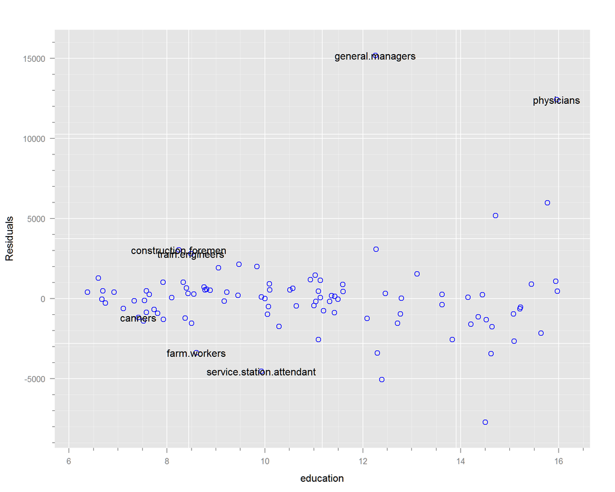

```r
plot(fit3, resid(.,type='r') ~ education, id = .1,
     idLabels = ~ occ)
```

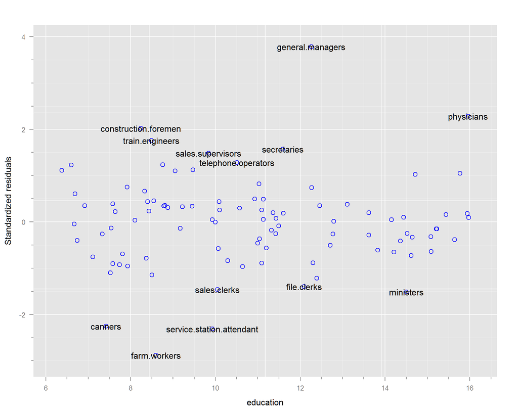

```r
plot(fit3, resid(.,type='p') ~ education,
     id = .2, idLabels = ~occ)
```

#### Model with quadratic terms in education and women

```r
fit3q <- update(fit3, . ~ type * (education * women + I(education^2) +I(women^2)))
summary(fit3q)
```

```
   Generalized least squares fit by REML
     Model: income ~ type + education + women + I(education^2) + I(women^2) +      education:women + type:education + type:women + type:I(education^2) +      type:I(women^2) + type:education:women
     Data: Prestige
          AIC      BIC    logLik
     1591.036 1638.677 -775.5182

   Variance function:
    Structure: Power of variance covariate
    Formula: ~fitted(.)
    Parameter estimates:
      power
   1.623285

   Coefficients:
                                Value Std.Error    t-value p-value
   (Intercept)               14657.47  10166.50  1.4417422  0.1533
   typeprof                  32541.82  71720.98  0.4537281  0.6513
   typewc                   -48907.80  31440.00 -1.5555918  0.1238
   education                 -2327.85   2403.83 -0.9683931  0.3358
   women                      -120.73     53.25 -2.2673993  0.0261
   I(education^2)              158.20    141.38  1.1190160  0.2665
   I(women^2)                    0.68      0.23  3.0146252  0.0034
   education:women               3.28      5.33  0.6151785  0.5402
   typeprof:education        -3553.19  10763.31 -0.3301203  0.7422
   typewc:education           8999.16   6189.47  1.4539463  0.1499
   typeprof:women             -361.94    387.19 -0.9347822  0.3527
   typewc:women                 52.47    119.06  0.4406923  0.6606
   typeprof:I(education^2)      89.71    410.27  0.2186494  0.8275
   typewc:I(education^2)      -401.08    307.59 -1.3039349  0.1960
   typeprof:I(women^2)           1.29      1.10  1.1785223  0.2421
   typewc:I(women^2)            -0.06      0.35 -0.1708094  0.8648
   typeprof:education:women     13.56     23.33  0.5813593  0.5626
   typewc:education:women       -8.76     11.97 -0.7319181  0.4664

    Correlation:
                            (Intr) typprf typewc eductn women  I(d^2) I(w^2) edctn: typprf:d
   typeprof                 -0.142
   typewc                   -0.323  0.046
   education                -0.993  0.141  0.321
   women                    -0.464  0.066  0.150  0.374
```

[output cut: 41 more lines]

```
   typeprof:women
   typewc:women
   typeprof:I(education^2)
   typewc:I(education^2)
   typeprof:I(women^2)
   typewc:I(women^2)         0.134
   typeprof:education:women  0.771         0.058
   typewc:education:women    0.036        -0.169        0.102

   Standardized residuals:
            Min           Q1          Med           Q3          Max
   -3.106940310 -0.472587959  0.009672639  0.478734944  3.583624020

   Residual standard error: 0.001075903
   Degrees of freedom: 98 total; 80 residual
```

**Exercise:** Have a look at diagnostics and describe what they tell you.

#### Model formulas in R

I had trouble finding a good discussion of model formulas in the text book. Here’s a link to a [page with some information](http://science.nature.nps.gov/im/datamgmt/statistics/r/formulas/). You can also get help in R with ‘?formula’.

Where in the textbook would you find the interpretation of the following terms in the predictor formula:

### Mathematical formula for a model

To interpret coefficients, we need to be able to write the mathematical prediction formula that corresponds to the model formula.

One aspect of this is understanding the **X** matrix generated by the formula:

```r
getX(fit3) %>% head  # top 6 rows
```

```
                       (Intercept) education women typeprof typewc education:women
   gov.administrators            1     13.11 11.16        1      0        146.3076
   general.managers              1     12.26  4.02        1      0         49.2852
   accountants                   1     12.77 15.70        1      0        200.4890
   purchasing.officers           1     11.42  9.11        1      0        104.0362
   chemists                      1     14.62 11.68        1      0        170.7616
   physicists                    1     15.64  5.13        1      0         80.2332
                       education:typeprof education:typewc women:typeprof women:typewc
   gov.administrators               13.11                0          11.16            0
   general.managers                 12.26                0           4.02            0
   accountants                      12.77                0          15.70            0
   purchasing.officers              11.42                0           9.11            0
   chemists                         14.62                0          11.68            0
   physicists                       15.64                0           5.13            0
```

```r
getX(fit3) %>% some  # from the 'car' package, prints 10 rows at random
```

```
                        (Intercept) education women typeprof typewc education:women
   biologists                     1     15.09 25.65        1      0        387.0585
   bookkeepers                    1     11.32 68.24        0      1        772.4768
   receptionsts                   1     11.04 92.86        0      1       1025.1744
   sales.supervisors              1      9.84 17.04        0      1        167.6736
   real.estate.salesmen           1     11.09 24.44        0      1        271.0396
   funeral.directors              1     10.57  6.01        0      0         63.5257
   tool.die.makers                1     10.09  1.50        0      0         15.1350
   construction.foremen           1      8.24  0.65        0      0          5.3560
   carpenters                     1      6.92  0.56        0      0          3.8752
   typesetters                    1     10.00 13.58        0      0        135.8000
                        education:typeprof education:typewc women:typeprof women:typewc
   biologists                        15.09             0.00          25.65         0.00
   bookkeepers                        0.00            11.32           0.00        68.24
   receptionsts                       0.00            11.04           0.00        92.86
   sales.supervisors                  0.00             9.84           0.00        17.04
   real.estate.salesmen               0.00            11.09           0.00        24.44
   funeral.directors                  0.00             0.00           0.00         0.00
   tool.die.makers                    0.00             0.00           0.00         0.00
   construction.foremen               0.00             0.00           0.00         0.00
   carpenters                         0.00             0.00           0.00         0.00
   typesetters                        0.00             0.00           0.00         0.00
```

```r
getX(fit3q) %>% head
```

```
                       (Intercept) typeprof typewc education women I(education^2) I(women^2)
   gov.administrators            1        1      0     13.11 11.16       171.8721   124.5456
   general.managers              1        1      0     12.26  4.02       150.3076    16.1604
   accountants                   1        1      0     12.77 15.70       163.0729   246.4900
   purchasing.officers           1        1      0     11.42  9.11       130.4164    82.9921
   chemists                      1        1      0     14.62 11.68       213.7444   136.4224
   physicists                    1        1      0     15.64  5.13       244.6096    26.3169
                       education:women typeprof:education typewc:education typeprof:women
   gov.administrators         146.3076              13.11                0          11.16
   general.managers            49.2852              12.26                0           4.02
   accountants                200.4890              12.77                0          15.70
   purchasing.officers        104.0362              11.42                0           9.11
   chemists                   170.7616              14.62                0          11.68
   physicists                  80.2332              15.64                0           5.13
                       typewc:women typeprof:I(education^2) typewc:I(education^2)
   gov.administrators             0                171.8721                     0
   general.managers               0                150.3076                     0
   accountants                    0                163.0729                     0
   purchasing.officers            0                130.4164                     0
   chemists                       0                213.7444                     0
   physicists                     0                244.6096                     0
                       typeprof:I(women^2) typewc:I(women^2) typeprof:education:women
   gov.administrators             124.5456                 0                 146.3076
   general.managers                16.1604                 0                  49.2852
   accountants                    246.4900                 0                 200.4890
   purchasing.officers             82.9921                 0                 104.0362
   chemists                       136.4224                 0                 170.7616
   physicists                      26.3169                 0                  80.2332
                       typewc:education:women
   gov.administrators                       0
   general.managers                         0
   accountants                              0
   purchasing.officers                      0
   chemists                                 0
   physicists                               0
```

The mathematical formula for ‘fit3q’, to pick a complex one, is

$$\begin{aligned}
\operatorname{E} (Y|W,E,T) =
& {\beta _0} + {\beta _1}{T_p} + {\beta _2}{T_w} + {\beta _3}E
+ {\beta _4}W + {\beta _5}{E^2} + {\beta _6}{W^2} + {\beta _7}EW \\
& + {\beta _8}{T_p}E + {\beta _9}{T_w}E + {\beta _{10}}{T_p}W
+ {\beta _{11}}{T_w}W + {\beta _{12}}{T_p}{E^2} + {\beta _{13}}{T_w}{E^2} \\
& + {\beta _{14}}{T_p}{W^2} + {\beta _{15}}{T_w}{W^2} + {\beta _{16}}{T_p}EW + {\beta _{17}}{T_w}EW \\
\end{aligned}$$

where ${T_p} = 1$ if the occupation type is ‘professional’ and 0 otherwise and, similary for $T_w$ and ‘white collar’. Note that ‘blue collar’ is the *reference level*, i.e. the one that occupation type that correspondss to $T_p = T_w = 0$. With factors in R, the reference level is the first level of the factor, e.g.

```r
levels(Prestige$type)
```

```
   [1] "bc"   "prof" "wc"
```

### General Linear Hypotheses and Estimators using Wald Tests

Once we express the formula mathematically, it is easy to see how we could use the model to ask all sorts of questions. For example, what is the increase in income associated with an increase in education for a professional occupation that has no women? It is the *partial derivative* of $\operatorname{E}(Y|W,E,T)$ with respect to $E$:

$$\frac{\partial}{{\partial E}}\operatorname{E} (Y|W,E,T{\left. ) \right|_{W = 0;T = p}}$$

This, in general, will be a function of $W$, $E$ and $T$. So, for example, the association of income with education for a professional male occupation is:

$$\frac{\partial}{{\partial E}}\operatorname{E} (Y|W,E,T{\left. ) \right|_{W = 0;T = p}}$$

which may depend on $E$.

Thus there isn’t a single number that describes the ‘effect’ of education. The ‘effect’ depends on the context. We can estimate the coefficient for this association by differentiating with respect to $E$ and and setting $W=0$, $T_p = 1$ and $T_w = 0$:

$$\begin{aligned}
\frac{\partial}{{\partial E}}\operatorname{E} (Y|W,E,T{\left. ) \right|_{W = 0;T = p}} =
& {\beta _3} + 2{\beta _5}E + {\beta _7}W \\
& + {\beta _8}{T_p} + {\beta _9}{T_w} + 2{\beta _{12}}{T_p}E + 2{\beta _{13}}{T_w}E \\
& + {\beta _{16}}{T_p}W + {\beta _{17}}{T_w}W \\
\end{aligned}$$

We estimate this using the ‘General Linear Hypothesis’ as a linear combination of the vector of $\beta$s.

For example, to estimate the ‘value of an extra year’ when $E = 10$, we find
$$\hat{\eta} = L \hat{\beta} = \left[ {\begin{array}{*{20}{c}}
0&0&0&1&0&{20}&0&0&1&0&0&0&20&0&0&0&0&0
\end{array}} \right]\left[ {\begin{array}{*{20}{c}}
{{\hat{\beta} _0}} \\
{{\hat{\beta} _1}} \\
{{\hat{\beta} _2}} \\
{{\hat{\beta} _3}} \\
{{\hat{\beta} _4}} \\
{{\hat{\beta} _5}} \\
{{\hat{\beta} _6}} \\
{{\hat{\beta} _7}} \\
{{\hat{\beta} _8}} \\
{{\hat{\beta} _9}} \\
{{\hat{\beta} _{10}}} \\
{{\hat{\beta} _{11}}} \\
{{\hat{\beta} _{12}}} \\
{{\hat{\beta} _{13}}} \\
{{\hat{\beta} _{14}}} \\
{{\hat{\beta} _{15}}} \\
{{\hat{\beta} _{16}}} \\
{{\hat{\beta} _{17}}}
\end{array}} \right]$$

To estimate the variance of $\hat{\eta}$ we use $L \hat{Var}(\hat{\beta}) L'$.

In R, we can do this with matrix multiplication:

```r
L <- rbind("assoc. with Educ | male prof. E=10" = c(0,0,0,1,0,20,0,0,1,0,0,0,20,0,0,0,0,0))
L
```

```
                                      [,1] [,2] [,3] [,4] [,5] [,6] [,7] [,8] [,9] [,10]
   assoc. with Educ | male prof. E=10    0    0    0    1    0   20    0    0    1     0
                                      [,11] [,12] [,13] [,14] [,15] [,16] [,17] [,18]
   assoc. with Educ | male prof. E=10     0     0    20     0     0     0     0     0
```

With a ‘gls’ fit, we extract $\hat{\beta}$ with:

```r
coef(fit3q)
```

```
                (Intercept)                 typeprof                   typewc
               1.465747e+04             3.254182e+04            -4.890780e+04
                  education                    women           I(education^2)
              -2.327853e+03            -1.207349e+02             1.582022e+02
                 I(women^2)          education:women       typeprof:education
               6.836437e-01             3.281036e+00            -3.553188e+03
           typewc:education           typeprof:women             typewc:women
               8.999158e+03            -3.619389e+02             5.246681e+01
    typeprof:I(education^2)    typewc:I(education^2)      typeprof:I(women^2)
               8.970572e+01            -4.010784e+02             1.292266e+00
          typewc:I(women^2) typeprof:education:women   typewc:education:women
              -6.000094e-02             1.356272e+01            -8.760494e+00
```

So the estimate is:

```r
L %*% coef(fit3q)
```

```
                                           [,1]
   assoc. with Educ | male prof. E=10 -922.8829
```

Wow! – don’t do it!

Now for the variance … but there are functions that make this easier, ‘lht’ in ‘car’ and ‘wald’ in ‘spida2’:

```r
wald(fit3q, L)
```

```
     numDF denDF   F.value p.value
   1     1    79 0.1052936 0.74642

                                         Estimate Std.Error DF  t-value p-value Lower 0.95
     assoc. with Educ | male prof. E=10 -922.8829  2844.105 79 -0.32449 0.74642  -6583.933

                                        Upper 0.95
     assoc. with Educ | male prof. E=10   4738.167
```

What could be happening?

We could explore the association with education for various values of E, W and T by building a larger L matrix. e.g.

```r
L <- rbind(
  'male prof E=10' = c(0,0,0,1,0,20,0,0,1,0,0,0,20,0,0,0,0,0),
  'male prof E=12' = c(0,0,0,1,0,24,0,0,1,0,0,0,24,0,0,0,0,0),
  'male prof E=14' = c(0,0,0,1,0,28,0,0,1,0,0,0,28,0,0,0,0,0),
  'male prof E=16' = c(0,0,0,1,0,32,0,0,1,0,0,0,32,0,0,0,0,0))
wald(fit3q,L)
```

```
     numDF denDF  F.value p.value
   1     2    79 1.073832 0.34663

                     Estimate Std.Error DF   t-value p-value Lower 0.95 Upper 0.95
     male prof E=10 -922.8829 2844.1054 79 -0.324490 0.74642 -6583.9331   4738.167
     male prof E=12   68.7487 1390.2812 79  0.049449 0.96069 -2698.5369   2836.034
     male prof E=14 1060.3803  723.5874 79  1.465449 0.14677  -379.8843   2500.645
     male prof E=16 2052.0120 1964.9493 79  1.044308 0.29953 -1859.1218   5963.146
```

But this would be extremely laborious.

Let’s see the fitted model for various combination of education, women and type

First, create a data frame with the combinations for which we want to estimate the fit:

```r
pred <- expand.grid(women = seq(0,100,20), education = seq(6,18,.2), type = levels(Prestige$type))
```

‘pred’ is a data frame with the Cartesian product of its arguments

```r
dim(pred)
```

```
   [1] 1098    3
```

```r
head(pred,10)
```

```
      women education type
   1      0       6.0   bc
   2     20       6.0   bc
   3     40       6.0   bc
   4     60       6.0   bc
   5     80       6.0   bc
   6    100       6.0   bc
   7      0       6.2   bc
   8     20       6.2   bc
   9     40       6.2   bc
   10    60       6.2   bc
```

```r
tail(pred,10)
```

```
        women education type
   1089    40      17.8   wc
   1090    60      17.8   wc
   1091    80      17.8   wc
   1092   100      17.8   wc
   1093     0      18.0   wc
   1094    20      18.0   wc
   1095    40      18.0   wc
   1096    60      18.0   wc
   1097    80      18.0   wc
   1098   100      18.0   wc
```

Now we add predicted income using our model:

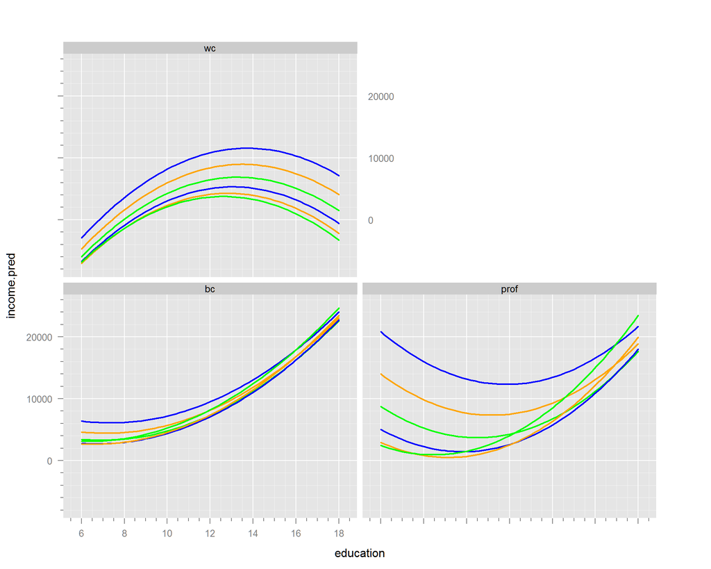

```r
pred$income.pred <- predict(fit3q, newdata = pred)
xyplot(income.pred ~ education | type, pred, groups = women, type = 'l')
```